# Clase 8 de Métodos Numéricos 15-10-2025

Diana Laura Pais Felipe Matrícula:23-002-0030

17 octubre, 2025

```r
N <- 1000
a <- -10
b <- 10
paso <- 0.01
x <- seq(a,b,paso); (x)
```

[output not shown]

[output cut: 186 more lines]

```r
head(x,10)
```

```
##  [1] -10.00  -9.99  -9.98  -9.97  -9.96  -9.95  -9.94  -9.93  -9.92  -9.91
```

Graficamos la función cúbica de $f(x)=-x^{3}-6x^{2}+11x-6$

```r
A <- -1
B <- -6
C <- 11
D <- -6

f_x <- A*(x^3)+B*(x^2)+C*x+D
head(f_x,10)
```

```
##  [1] 284.0000 282.3124 280.6296 278.9516 277.2783 275.6099 273.9462 272.2873
##  [9] 270.6331 268.9837
```

Graficamos la función

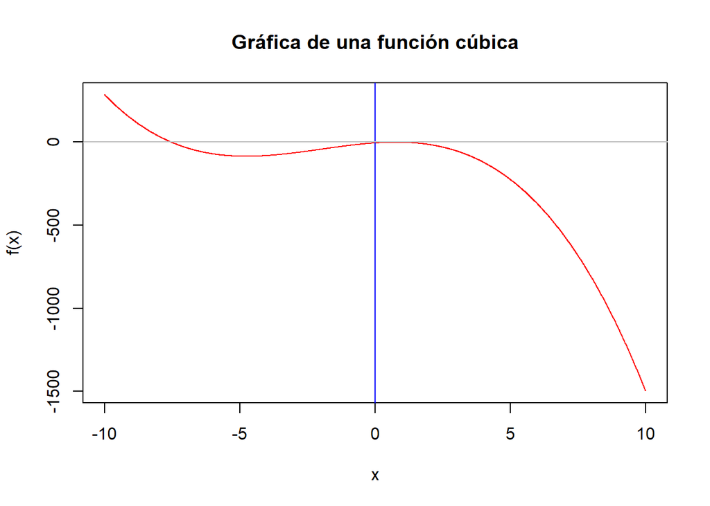

```r
plot(x,f_x, col = "red",
     main = "Gráfica de una función cúbica",
     type = "l",
     xlab = "x",
     ylab = "f(x)")
abline(v = 0, type = "-", col = "blue")
abline(h = 0, type = "-", col = "gray")
```

Búsqueda de la raíz, después de revisar la gráfica, en el intervalo $[-9,-5]$

```r
a <- -9
b <- -5
```

Empezamos con el método de bisección: $c=\frac{a+b}{2}$

```r
c <- (a + b) / 2;
print(c)
```

```
## [1] -7
```

Definimos la función $\textit{f_cubica}$ para evaluar nuestra cúbica en los puntos de interés

```r
f_cubica <- function(x){
  A*(x^3)+B*(x^2)+(C*x)+D
}
```

Evaluamos nuestra función, en R, en los puntos $a$ y $b$

```r
fa <- f_cubica(a); print(fa)
```

```
## [1] 138
```

```r
fb <- f_cubica(b); print(fb)
```

```
## [1] -86
```

```r
fc <- f_cubica(c); print(fc)
```

```
## [1] -34
```

```r
signo_fafc <- sign(fa*fc); print(signo_fafc)
```

```
## [1] -1
```

```r
signo_fbfc <- sign(fb*fc); print(signo_fbfc)
```

```
## [1] 1
```

```r
error <- (a - b) / 2; print(error)
```

```
## [1] -2
```

Como $fa*fc<0$ y $fb*fc>0$ hacemos la asignación $b\leftarrow c$, y calculamos el nuevo valor de $c$

```r
b <- c; print(b)
```

```
## [1] -7
```

```r
c <- (a+b) / 2; print(c)
```

```
## [1] -8
```

Evaluamos nuevamente la cúbica en $a$, $b$ y $c$

```r
fa <- f_cubica(a); print(fa)
```

```
## [1] 138
```

```r
fb <- f_cubica(b); print(fb)
```

```
## [1] -34
```

```r
fc <- f_cubica(c); print(fc)
```

```
## [1] 34
```

```r
signo_fafc <- sign(fa*fc); print(signo_fafc)
```

```
## [1] 1
```

```r
signo_fbfc <- sign(fb*fc); print(signo_fbfc)
```

```
## [1] -1
```

```r
error <- (a - b) / 2; print(error)
```

```
## [1] -1
```

Como $fb*fc<0$ y $fa*fc>0$ hacemos la asignación $a\leftarrow c$, y calculamos el nuevo valor de $c$

```r
a <- c; print(a)
```

```
## [1] -8
```

```r
c <- (a+b) / 2; print(c)
```

```
## [1] -7.5
```

Evaluamos nuevamente la cúbica en $a$, $b$ y $c$

```r
fa <- f_cubica(a); print(fa)
```

```
## [1] 34
```

```r
fb <- f_cubica(b); print(fb)
```

```
## [1] -34
```

```r
fc <- f_cubica(c); print(fc)
```

```
## [1] -4.125
```

```r
signo_fafc <- sign(fa*fc); print(signo_fafc)
```

```
## [1] -1
```

```r
signo_fbfc <- sign(fb*fc); print(signo_fbfc)
```

```
## [1] 1
```

```r
error <- (a - b) / 2; print(error)
```

```
## [1] -0.5
```

Como $fa*fc<0$ y $fb*fc>0$ hacemos la asignación $b\leftarrow c$, y calculamos el nuevo valor de $c$

```r
b <- c; print(b)
```

```
## [1] -7.5
```

```r
c <- (a+b) / 2; print(c)
```

```
## [1] -7.75
```

Evaluamos nuevamente la cúbica en $a$, $b$ y $c$

```r
fa <- f_cubica(a); print(fa)
```

```
## [1] 34
```

```r
fb <- f_cubica(b); print(fb)
```

```
## [1] -4.125
```

```r
fc <- f_cubica(c); print(fc)
```

```
## [1] 13.85938
```

```r
signo_fafc <- sign(fa*fc); print(signo_fafc)
```

```
## [1] 1
```

```r
signo_fbfc <- sign(fb*fc); print(signo_fbfc)
```

```
## [1] -1
```

```r
error <- (a - b) / 2; print(error)
```

```
## [1] -0.25
```

Como $fb*fc<0$ y $fa*fc>0$ hacemos la asignación $a\leftarrow c$, y calculamos el nuevo valor de $c$

```r
a <- c; print(a)
```

```
## [1] -7.75
```

```r
c <- (a+b) / 2; print(c)
```

```
## [1] -7.625
```

Evaluamos nuevamente la cúbica en $a$, $b$ y $c$

```r
fa <- f_cubica(a); print(fa)
```

```
## [1] 13.85938
```

```r
fb <- f_cubica(b); print(fb)
```

```
## [1] -4.125
```

```r
fc <- f_cubica(c); print(fc)
```

```
## [1] 4.603516
```

```r
signo_fafc <- sign(fa*fc); print(signo_fafc)
```

```
## [1] 1
```

```r
signo_fbfc <- sign(fb*fc); print(signo_fbfc)
```

```
## [1] -1
```

```r
error <- (a - b) / 2; print(error)
```

```
## [1] -0.125
```

Como $fb*fc<0$ y $fa*fc>0$ hacemos la asignación $a\leftarrow c$, y calculamos el nuevo valor de $c$

```r
a <- c; print(a)
```

```
## [1] -7.625
```

```r
c <- (a+b) / 2; print(c)
```

```
## [1] -7.5625
```

Evaluamos nuevamente la cúbica en $a$, $b$ y $c$

```r
fa <- f_cubica(a); print(fa)
```

```
## [1] 4.603516
```

```r
fb <- f_cubica(b); print(fb)
```

```
## [1] -4.125
```

```r
fc <- f_cubica(c); print(fc)
```

```
## [1] 0.1740723
```

```r
signo_fafc <- sign(fa*fc); print(signo_fafc)
```

```
## [1] 1
```

```r
signo_fbfc <- sign(fb*fc); print(signo_fbfc)
```

```
## [1] -1
```

```r
error <- (a - b) / 2; print(error)
```

```
## [1] -0.0625
```

Como $fb*fc<0$ y $fa*fc>0$ hacemos la asignación $a\leftarrow c$, y calculamos el nuevo valor de $c$

```r
a <- c; print(a)
```

```
## [1] -7.5625
```

```r
c <- (a+b) / 2; print(c)
```

```
## [1] -7.53125
```

Evaluamos nuevamente la cúbica en $a$, $b$ y $c$

```r
fa <- f_cubica(a); print(fa)
```

```
## [1] 0.1740723
```

```r
fb <- f_cubica(b); print(fb)
```

```
## [1] -4.125
```

```r
fc <- f_cubica(c); print(fc)
```

```
## [1] -1.991669
```

```r
signo_fafc <- sign(fa*fc); print(signo_fafc)
```

```
## [1] -1
```

```r
signo_fbfc <- sign(fb*fc); print(signo_fbfc)
```

```
## [1] 1
```

```r
error <- (a - b) / 2; print(error)
```

```
## [1] -0.03125
```

Como $fa*fc<0$ y $fb*fc>0$ hacemos la asignación $b\leftarrow c$, y calculamos el nuevo valor de $c$

```r
b <- c; print(b)
```

```
## [1] -7.53125
```

```r
c <- (a+b) / 2; print(c)
```

```
## [1] -7.546875
```

Evaluamos nuevamente la cúbica en $a$, $b$ y $c$

```r
fa <- f_cubica(a); print(fa)
```

```
## [1] 0.1740723
```

```r
fb <- f_cubica(b); print(fb)
```

```
## [1] -1.991669
```

```r
fc <- f_cubica(c); print(fc)
```

```
## [1] -0.9128609
```

```r
signo_fafc <- sign(fa*fc); print(signo_fafc)
```

```
## [1] -1
```

```r
signo_fbfc <- sign(fb*fc); print(signo_fbfc)
```

```
## [1] 1
```

```r
error <- (a - b) / 2; print(error)
```

```
## [1] -0.015625
```

Como $fa*fc<0$ y $fb*fc>0$ hacemos la asignación $b\leftarrow c$, y calculamos el nuevo valor de $c$

```r
b <- c; print(b)
```

```
## [1] -7.546875
```

```r
c <- (a+b) / 2; print(c)
```

```
## [1] -7.554688
```

Evaluamos nuevamente la cúbica en $a$, $b$ y $c$

```r
fa <- f_cubica(a); print(fa)
```

```
## [1] 0.1740723
```

```r
fb <- f_cubica(b); print(fb)
```

```
## [1] -0.9128609
```

```r
fc <- f_cubica(c); print(fc)
```

```
## [1] -0.3704114
```

```r
signo_fafc <- sign(fa*fc); print(signo_fafc)
```

```
## [1] -1
```

```r
signo_fbfc <- sign(fb*fc); print(signo_fbfc)
```

```
## [1] 1
```

```r
error <- (a - b) / 2; print(error)
```

```
## [1] -0.0078125
```

Como $fa*fc<0$ y $fb*fc>0$ hacemos la asignación $b\leftarrow c$, y calculamos el nuevo valor de $c$

```r
b <- c; print(b)
```

```
## [1] -7.554688
```

```r
c <- (a+b) / 2; print(c)
```

```
## [1] -7.558594
```

Evaluamos nuevamente la cúbica en $a$, $b$ y $c$

```r
fa <- f_cubica(a); print(fa)
```

```
## [1] 0.1740723
```

```r
fb <- f_cubica(b); print(fb)
```

```
## [1] -0.3704114
```

```r
fc <- f_cubica(c); print(fc)
```

```
## [1] -0.09842402
```

```r
signo_fafc <- sign(fa*fc); print(signo_fafc)
```

```
## [1] -1
```

```r
signo_fbfc <- sign(fb*fc); print(signo_fbfc)
```

```
## [1] 1
```

```r
error <- (a - b) / 2; print(error)
```

```
## [1] -0.00390625
```

Como $fa*fc<0$ y $fb*fc>0$ hacemos la asignación $b\leftarrow c$, y calculamos el nuevo valor de $c$

```r
b <- c; print(b)
```

```
## [1] -7.558594
```

```r
c <- (a+b) / 2; print(c)
```

```
## [1] -7.560547
```

Evaluamos nuevamente la cúbica en $a$, $b$ y $c$

```r
fa <- f_cubica(a); print(fa)
```

```
## [1] 0.1740723
```

```r
fb <- f_cubica(b); print(fb)
```

```
## [1] -0.09842402
```

```r
fc <- f_cubica(c); print(fc)
```

```
## [1] 0.03776049
```

```r
signo_fafc <- sign(fa*fc); print(signo_fafc)
```

```
## [1] 1
```

```r
signo_fbfc <- sign(fb*fc); print(signo_fbfc)
```

```
## [1] -1
```

```r
error <- (a - b) / 2; print(error)
```

```
## [1] -0.001953125
```

Como $fb*fc<0$ y $fa*fc>0$ hacemos la asignación $a\leftarrow c$, y calculamos el nuevo valor de $c$

```r
a <- c; print(a)
```

```
## [1] -7.560547
```

```r
c <- (a+b) / 2; print(c)
```

```
## [1] -7.55957
```

Evaluamos nuevamente la cúbica en $a$, $b$ y $c$

```r
fa <- f_cubica(a); print(fa)
```

```
## [1] 0.03776049
```

```r
fb <- f_cubica(b); print(fb)
```

```
## [1] -0.09842402
```

```r
fc <- f_cubica(c); print(fc)
```

```
## [1] -0.03034767
```

```r
signo_fafc <- sign(fa*fc); print(signo_fafc)
```

```
## [1] -1
```

```r
signo_fbfc <- sign(fb*fc); print(signo_fbfc)
```

```
## [1] 1
```

```r
error <- (a - b) / 2; print(error)
```

```
## [1] -0.0009765625
```

Como $fa*fc<0$ y $fb*fc>0$ hacemos la asignación $b\leftarrow c$, y calculamos el nuevo valor de $c$

```r
b <- c; print(b)
```

```
## [1] -7.55957
```

```r
c <- (a+b) / 2; print(c)
```

```
## [1] -7.560059
```

Evaluamos nuevamente la cúbica en $a$, $b$ y $c$

```r
fa <- f_cubica(a); print(fa)
```

```
## [1] 0.03776049
```

```r
fb <- f_cubica(b); print(fb)
```

```
## [1] -0.03034767
```

```r
fc <- f_cubica(c); print(fc)
```

```
## [1] 0.003702432
```

```r
signo_fafc <- sign(fa*fc); print(signo_fafc)
```

```
## [1] 1
```

```r
signo_fbfc <- sign(fb*fc); print(signo_fbfc)
```

```
## [1] -1
```

```r
error <- (a - b) / 2; print(error)
```

```
## [1] -0.0004882812
```

Como $fb*fc<0$ y $fa*fc>0$ hacemos la asignación $a\leftarrow c$, y calculamos el nuevo valor de $c$

```r
a <- c; print(a)
```

```
## [1] -7.560059
```

```r
c <- (a+b) / 2; print(c)
```

```
## [1] -7.559814
```

Evaluamos nuevamente la cúbica en $a$, $b$ y $c$

```r
fa <- f_cubica(a); print(fa)
```

```
## [1] 0.003702432
```

```r
fb <- f_cubica(b); print(fb)
```

```
## [1] -0.03034767
```

```r
fc <- f_cubica(c); print(fc)
```

```
## [1] -0.01332361
```

```r
signo_fafc <- sign(fa*fc); print(signo_fafc)
```

```
## [1] -1
```

```r
signo_fbfc <- sign(fb*fc); print(signo_fbfc)
```

```
## [1] 1
```

```r
error <- (a - b) / 2; print(error)
```

```
## [1] -0.0002441406
```

Como $fa*fc<0$ y $fb*fc>0$ hacemos la asignación $b\leftarrow c$, y calculamos el nuevo valor de $c$

```r
b <- c; print(b)
```

```
## [1] -7.559814
```

```r
c <- (a+b) / 2; print(c)
```

```
## [1] -7.559937
```

Evaluamos nuevamente la cúbica en $a$, $b$ y $c$

```r
fa <- f_cubica(a); print(fa)
```

```
## [1] 0.003702432
```

```r
fb <- f_cubica(b); print(fb)
```

```
## [1] -0.01332361
```

```r
fc <- f_cubica(c); print(fc)
```

```
## [1] -0.004810839
```

```r
signo_fafc <- sign(fa*fc); print(signo_fafc)
```

```
## [1] -1
```

```r
signo_fbfc <- sign(fb*fc); print(signo_fbfc)
```

```
## [1] 1
```

```r
error <- (a - b) / 2; print(error)
```

```
## [1] -0.0001220703
```

Como $fa*fc<0$ y $fb*fc>0$ hacemos la asignación $b\leftarrow c$, y calculamos el nuevo valor de $c$

```r
b <- c; print(b)
```

```
## [1] -7.559937
```

```r
c <- (a+b) / 2; print(c)
```

```
## [1] -7.559998
```

Evaluamos nuevamente la cúbica en $a$, $b$ y $c$

```r
fa <- f_cubica(a); print(fa)
```

```
## [1] 0.003702432
```

```r
fb <- f_cubica(b); print(fb)
```

```
## [1] -0.004810839
```

```r
fc <- f_cubica(c); print(fc)
```

```
## [1] -0.0005542655
```

```r
signo_fafc <- sign(fa*fc); print(signo_fafc)
```

```
## [1] -1
```

```r
signo_fbfc <- sign(fb*fc); print(signo_fbfc)
```

```
## [1] 1
```

```r
error <- (a - b) / 2; print(error)
```

```
## [1] -6.103516e-05
```

Como $fa*fc<0$ y $fb*fc>0$ hacemos la asignación $b\leftarrow c$, y calculamos el nuevo valor de $c$

```r
b <- c; print(b)
```

```
## [1] -7.559998
```

```r
c <- (a+b) / 2; print(c)
```

```
## [1] -7.560028
```

Evaluamos nuevamente la cúbica en $a$, $b$ y $c$

```r
fa <- f_cubica(a); print(fa)
```

```
## [1] 0.003702432
```

```r
fb <- f_cubica(b); print(fb)
```

```
## [1] -0.0005542655
```

```r
fc <- f_cubica(c); print(fc)
```

```
## [1] 0.001574068
```

```r
signo_fafc <- sign(fa*fc); print(signo_fafc)
```

```
## [1] 1
```

```r
signo_fbfc <- sign(fb*fc); print(signo_fbfc)
```

```
## [1] -1
```

```r
error <- (a - b) / 2; print(error)
```

```
## [1] -3.051758e-05
```

Como $fb*fc<0$ y $fa*fc>0$ hacemos la asignación $a\leftarrow c$, y calculamos el nuevo valor de $c$

```r
a <- c; print(a)
```

```
## [1] -7.560028
```

```r
c <- (a+b) / 2; print(c)
```

```
## [1] -7.560013
```

Evaluamos nuevamente la cúbica en $a$, $b$ y $c$

```r
fa <- f_cubica(a); print(fa)
```

```
## [1] 0.001574068
```

```r
fb <- f_cubica(b); print(fb)
```

```
## [1] -0.0005542655
```

```r
fc <- f_cubica(c); print(fc)
```

```
## [1] 0.0005098973
```

```r
signo_fafc <- sign(fa*fc); print(signo_fafc)
```

```
## [1] 1
```

```r
signo_fbfc <- sign(fb*fc); print(signo_fbfc)
```

```
## [1] -1
```

```r
error <- (a - b) / 2; print(error)
```

```
## [1] -1.525879e-05
```

Como $fb*fc<0$ y $fa*fc>0$ hacemos la asignación $a\leftarrow c$, y calculamos el nuevo valor de $c$

```r
a <- c; print(a)
```

```
## [1] -7.560013
```

```r
c <- (a+b) / 2; print(c)
```

```
## [1] -7.560005
```

Evaluamos nuevamente la cúbica en $a$, $b$ y $c$

```r
fa <- f_cubica(a); print(fa)
```

```
## [1] 0.0005098973
```

```r
fb <- f_cubica(b); print(fb)
```

```
## [1] -0.0005542655
```

```r
fc <- f_cubica(c); print(fc)
```

```
## [1] -2.21851e-05
```

```r
signo_fafc <- sign(fa*fc); print(signo_fafc)
```

```
## [1] -1
```

```r
signo_fbfc <- sign(fb*fc); print(signo_fbfc)
```

```
## [1] 1
```

```r
error <- (a - b) / 2; print(error)
```

```
## [1] -7.629395e-06
```

Despúes de varias iteraciones y con un error de $−7.629395×10^{-6}$ ó $−0.000007629395$, obtuvimos que el valor de la raíz es: $-7.560005$.